# Tutorial 07 — Dosing Schedules

**Prerequisites:** Tutorials 01–06

**What you will learn**

## 1 Imports and shared model

```python
import numpy as np
import matplotlib.pyplot as plt

from pbisim import ModelBuilder, PBIModel, solve_ode, DoseEvent, DoseSchedule
from pbisim.analysis.single import plot_simulation

# Single-strain model with both phage (no PK) and antibiotic
def _base_cfg(phage_decay=0.1, abx_emax=4.0, abx_ec50=0.5):
    return (
        ModelBuilder(n_bacteria=1, n_phages=1, n_latent=5, n_depth=2)
        .with_growth_rates(1.0, bacteria_to_resource_ratio=1e9)
        .with_phage_params(adsorption_rates=2e-9, burst_sizes=50.0,
                           latent_periods=0.5, phage_decay_rates=phage_decay,
                           adsorption_rates_dormant=2e-11)
        .with_dormancy(dormancy_rate=0.15, resuscitation_rate=0.08,
                       dormancy_signal="nutrient", resuscitation_signal="nutrient")
        .with_antibiotic("cipro", k_elim=0.5, Vc=15.0, k12=0.4, k21=0.1,
                         emax=abx_emax, ec50=abx_ec50, hill=1.0,
                         emax_dormant=0.8, ec50_dormant=2.0)
        .with_nutrient(monod_constant=0.3, recycle_fraction=0.0)
    )

B0 = np.array([5e7])   # moderate inoculum
T_END = 72.0           # h
```

## 2 `DoseEvent` targets

The four dose targets and what they add to:

| `target` | State variable modified | Typical use |
| --- | --- | --- |
| `"phage"` | `P` (no PK) or `Pc` (with PK) | Phage bolus or infusion |
| `"antibiotic"` | `Ac[index]` (amount in central) | IV or oral antibiotic |
| `"nutrient"` | `S` | Chemostat nutrient addition |
| `"bacteria"` | `B[index]` | Inoculation, challenge models |

`amount` is the quantity added **instantaneously** (bolus). For infusions, use `route="infusion"` with a `duration` (hours): `DoseEvent(time=t_start, amount=total_amount, route="infusion", duration=hours, ...)`.

The four targets operate on different timescales, so they are best demonstrated in two focused simulations below.

### 2a `"phage"` and `"antibiotic"` targets

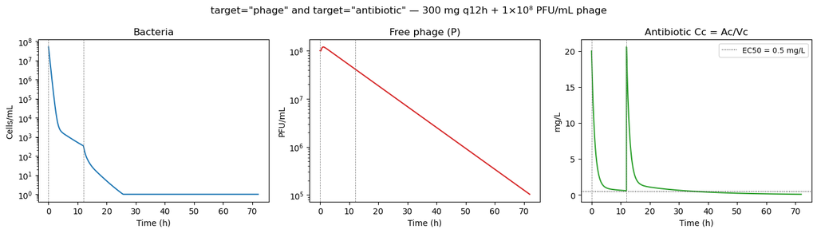

```python
# Phage and antibiotic targets: aggressive treatment shows rapid clearance
sched_phage_abx = DoseSchedule([
    DoseEvent(time=0,  amount=1e8,   target="phage",      index=0),
    DoseEvent(time=0,  amount=300.0, target="antibiotic",  index=0),   # 300mg → Cc=20mg/L
    DoseEvent(time=12, amount=300.0, target="antibiotic",  index=0),
])

cfg_pa = _base_cfg().with_dose_schedule(sched_phage_abx).build()
res_pa = solve_ode(
    PBIModel(cfg_pa, initial_B=B0, initial_P=np.array([0.0]), initial_S=1.0),
    t_end=T_END, dt=0.25,
)

VcABX = 15.0
fig, axes = plt.subplots(1, 3, figsize=(14, 4))
t = res_pa.time

axes[0].semilogy(t, np.maximum(res_pa.get("B0"), 1), "C0")
axes[0].set(xlabel="Time (h)", ylabel="Cells/mL", title="Bacteria")

axes[1].semilogy(t, np.maximum(res_pa.get("P0"), 1), "C3")
axes[1].set(xlabel="Time (h)", ylabel="PFU/mL", title="Free phage (P)")

Cc = res_pa.get("Ac0") / VcABX
axes[2].plot(t, np.maximum(Cc, 0), "C2")
axes[2].axhline(0.5, color="k", ls=":", lw=0.8, label="EC50 = 0.5 mg/L")
axes[2].set(xlabel="Time (h)", ylabel="mg/L",
            title="Antibiotic Cc = Ac/Vc")
axes[2].legend(fontsize=9)

for ax in axes:
    for t_d in [0, 12]:
        ax.axvline(t_d, color="gray", ls="--", lw=0.6)

plt.suptitle("target=\"phage\" and target=\"antibiotic\" — 300 mg q12h + 1×10⁸ PFU/mL phage")
plt.tight_layout()
plt.show()
```

### 2b `"nutrient"` and `"bacteria"` targets

The `"nutrient"` target adds directly to `S`. Its effect is most visible when bacteria have consumed most of the available nutrient and entered dormancy — a nutrient spike then **resuscitates dormant bacteria**, creating a second growth wave.

The `"bacteria"` target adds directly to `B[index]`, modelling a secondary inoculation or challenge.

Here we run a **bacteria-only** simulation (no phage or antibiotic) starting with low initial nutrient (`S₀ = 0.3`) to demonstrate both targets:

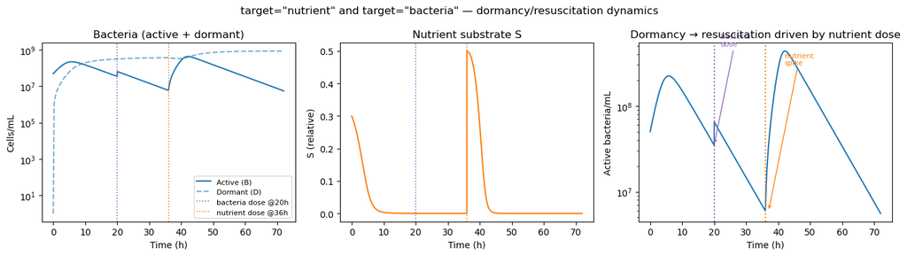

```
Active bacteria at t=35h (dormant state): 7.45e+06
Active bacteria at t=40h (post-spike):    1.62e+08  (22× increase)
```

```python
# Nutrient and bacteria targets:
# No phage/antibiotic pressure — only bacteria + nutrient dynamics.
# Start with low S=0.3 so bacteria deplete nutrients and enter dormancy
# within the first ~15 h.
sched_nutr_bac = DoseSchedule([
    DoseEvent(time=20, amount=3e7, target="bacteria", index=0),  # secondary inoculation
    DoseEvent(time=36, amount=0.5, target="nutrient"),            # nutrient replenishment
])

cfg_nb = _base_cfg().with_dose_schedule(sched_nutr_bac).build()
res_nb = solve_ode(
    PBIModel(cfg_nb, initial_B=B0, initial_P=np.array([0.0]), initial_S=0.3),
    t_end=T_END, dt=0.25,
)

fig, axes = plt.subplots(1, 3, figsize=(14, 4))
t = res_nb.time

B_active  = res_nb.get("B0")
B_dormant = sum(res_nb.get(f"D{d}_0") for d in range(2))

axes[0].semilogy(t, np.maximum(B_active,  1), "C0", label="Active (B)")
axes[0].semilogy(t, np.maximum(B_dormant, 1), "C0--", alpha=0.6, label="Dormant (D)")
axes[0].axvline(20, color="C4", ls=":", lw=1.2, label="bacteria dose @20h")
axes[0].axvline(36, color="C1", ls=":", lw=1.2, label="nutrient dose @36h")
axes[0].set(xlabel="Time (h)", ylabel="Cells/mL", title="Bacteria (active + dormant)")
axes[0].legend(fontsize=8)

axes[1].plot(t, res_nb.get("S"), "C1")
axes[1].axvline(20, color="C4", ls=":", lw=1.2)
axes[1].axvline(36, color="C1", ls=":", lw=1.2)
axes[1].set(xlabel="Time (h)", ylabel="S (relative)", title="Nutrient substrate S")

# Annotate the two dose events
axes[2].semilogy(t, np.maximum(B_active, 1), "C0")
axes[2].axvline(20, color="C4", ls=":", lw=1.5)
axes[2].axvline(36, color="C1", ls=":", lw=1.5)
axes[2].annotate("bacteria\ndose", xy=(20, float(B_active[int(20/0.25)])),
                 xytext=(22, 5e8), fontsize=8,
                 arrowprops=dict(arrowstyle="->", color="C4"), color="C4")
axes[2].annotate("nutrient\nspike", xy=(37, float(B_active[int(37/0.25)])),
                 xytext=(42, 3e8), fontsize=8,
                 arrowprops=dict(arrowstyle="->", color="C1"), color="C1")
axes[2].set(xlabel="Time (h)", ylabel="Active bacteria/mL",
            title="Dormancy → resuscitation driven by nutrient dose")

plt.suptitle("target=\"nutrient\" and target=\"bacteria\" — dormancy/resuscitation dynamics")
plt.tight_layout()
plt.show()

print(f"Active bacteria at t=35h (dormant state): {B_active[int(35/0.25)]:.2e}")
print(f"Active bacteria at t=40h (post-spike):    {B_active[int(40/0.25)]:.2e}  "
      f"({B_active[int(40/0.25)]/max(B_active[int(35/0.25)],1):.0f}× increase)")
```

## 3 Bolus vs continuous infusion

**Bolus** (single `amount`): maximum peak concentration, short exposure. Favoured for concentration-dependent antibiotics (fluoroquinolones, aminoglycosides) where high peak/MIC ratio predicts outcome.

**Infusion** (continuous `rate` over an interval): sustained plateau concentration. Favoured for time-dependent antibiotics (beta-lactams) where time above MIC drives efficacy.

For **phage**, infusion models a continuous vascular drip — clinically relevant for severe bacteraemia where phage elimination is rapid.

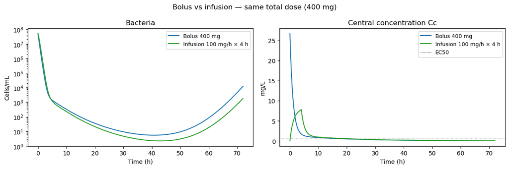

```python
# Compare: 400mg bolus vs 400mg infused over 4h (same total dose)
bolus_sched  = DoseSchedule([DoseEvent(time=0, amount=400.0, target="antibiotic", index=0)])
# 400 mg total infused over 4 h  (rate = 400/4 = 100 mg/h internally)
infuse_sched = DoseSchedule([DoseEvent(time=0, amount=400.0,
                                        route="infusion", duration=4.0,
                                        target="antibiotic", index=0)])

results_route = {}
for name, sched in [("Bolus 400 mg", bolus_sched),
                    ("Infusion 100 mg/h × 4 h", infuse_sched)]:
    cfg = _base_cfg().with_dose_schedule(sched).build()
    res = solve_ode(
        PBIModel(cfg, initial_B=B0, initial_P=np.array([0.0]), initial_S=1.0),
        t_end=T_END, dt=0.25,
    )
    results_route[name] = res

fig, axes = plt.subplots(1, 2, figsize=(12, 4))
colors = ["C0", "C2"]
for (name, res), color in zip(results_route.items(), colors):
    axes[0].semilogy(res.time, np.maximum(res.get("B0"), 1),  color=color, label=name)
    Cc = res.get("Ac0") / 15.0
    axes[1].plot(res.time, np.maximum(Cc, 0), color=color, label=name)
axes[1].axhline(0.5, ls=":", color="k", lw=0.8, label="EC50")
axes[0].set(xlabel="Time (h)", ylabel="Cells/mL", title="Bacteria")
axes[1].set(xlabel="Time (h)", ylabel="mg/L", title="Central concentration Cc")
for ax in axes: ax.legend(fontsize=9)
plt.suptitle("Bolus vs infusion — same total dose (400 mg)")
plt.tight_layout()
plt.show()
```

## 4 Clinical antibiotic regimens

Real clinical regimens use multiple doses separated by fixed intervals. A **loading dose** is often given first to rapidly achieve therapeutic concentrations, followed by smaller maintenance doses.

The dose interval should be chosen so that concentrations stay above the MIC for a sufficient fraction of the dosing interval (time-dependent drugs) or peak concentrations remain high (concentration-dependent drugs).

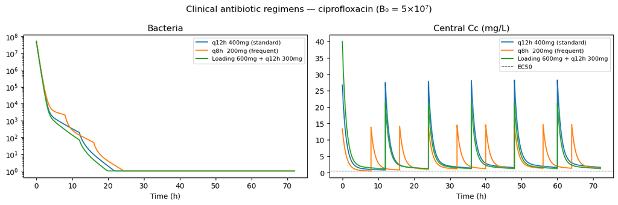

```python
def _abx_only(doses_mg_times):
    sched = DoseSchedule([
        DoseEvent(time=t, amount=mg, target="antibiotic", index=0)
        for t, mg in doses_mg_times
    ])
    cfg = _base_cfg().with_dose_schedule(sched).build()
    return solve_ode(
        PBIModel(cfg, initial_B=B0, initial_P=np.array([0.0]), initial_S=1.0),
        t_end=T_END, dt=0.25,
    )

regimens = {
    "q12h 400mg (standard)":    [(0,400),(12,400),(24,400),(36,400),(48,400),(60,400)],
    "q8h  200mg (frequent)":    [(t,200) for t in range(0, 72, 8)],
    "Loading 600mg + q12h 300mg": [(0,600)]+[(t,300) for t in range(12,72,12)],
}

fig, axes = plt.subplots(1, 2, figsize=(12, 4))
for (name, doses), color in zip(regimens.items(), ["C0","C1","C2"]):
    res = _abx_only(doses)
    axes[0].semilogy(res.time, np.maximum(res.get("B0"), 1),  color=color, label=name)
    axes[1].plot(res.time, np.maximum(res.get("Ac0")/15.0, 0), color=color, label=name)
axes[1].axhline(0.5, ls=":", color="k", lw=0.8, label="EC50")
for ax, title in zip(axes, ["Bacteria", "Central Cc (mg/L)"]):
    ax.set(xlabel="Time (h)", ylabel="", title=title)
    ax.legend(fontsize=8)
plt.suptitle("Clinical antibiotic regimens — ciprofloxacin (B₀ = 5×10⁷)")
plt.tight_layout()
plt.show()
```

## 5 Phage–antibiotic combination timing

**Phage-antibiotic synergy (PAS)** is well documented: phage kill replicating bacteria, lysing them and releasing sub-inhibitory antibiotic concentrations into the local environment; antibiotics then mop up dormant bacteria and resistant minority populations.

**Key timing questions:**

- Simultaneous vs phage-first vs antibiotic-first
- Should phage be re-dosed?

**Expected biology:**

- Phage first → bacteria suppressed before antibiotic → lower mutant selection
- Antibiotic first → partially inhibits bacteria (reduced burst?) → fewer phage targets
- Simultaneous → synergistic killing if non-antagonistic
- Phage re-dose → sustains phage pressure after blood clearance

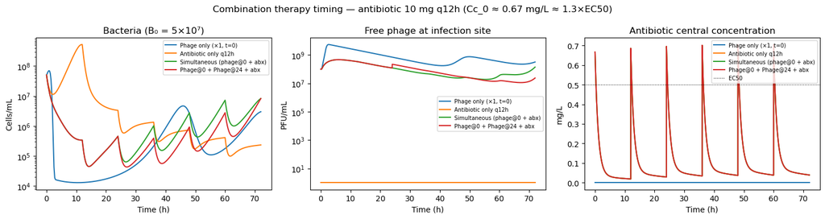

```python
def _combo_run(phage_times, abx_times_mg):
    events = []
    for t in phage_times:
        events.append(DoseEvent(time=t, amount=1e8, target="phage", index=0))
    for t, mg in abx_times_mg:
        events.append(DoseEvent(time=t, amount=mg, target="antibiotic", index=0))
    sched = DoseSchedule(events)
    cfg = _base_cfg().with_dose_schedule(sched).build()
    return solve_ode(
        PBIModel(cfg, initial_B=B0, initial_P=np.array([0.0]), initial_S=1.0),
        t_end=T_END, dt=0.25,
    )

# Low dose (10 mg) so that combination timing makes a visible difference.
# With Vc=15, Cc_0 = 10/15 ≈ 0.67 mg/L ≈ 1.3 × EC50 — sub-maximal killing.
abx_q12 = [(t, 10) for t in range(0, 72, 12)]

combos = {
    "Phage only (×1, t=0)":         ([0],        []),
    "Antibiotic only q12h":          ([],         abx_q12),
    "Simultaneous (phage@0 + abx)":  ([0],        abx_q12),
    "Phage@0 + Phage@24 + abx":      ([0, 24],    abx_q12),
}

results_combo = {}
for name, (ph_t, abx_t) in combos.items():
    results_combo[name] = _combo_run(ph_t, abx_t)

fig, axes = plt.subplots(1, 3, figsize=(15, 4))
colors = ["C0","C1","C2","C3"]
VcABX = 15.0

for (name, res), color in zip(results_combo.items(), colors):
    axes[0].semilogy(res.time, np.maximum(res.get("B0"), 1),  color=color, label=name)
    axes[1].semilogy(res.time, np.maximum(res.get("P0"), 1),  color=color, label=name)
    Cc = np.maximum(res.get("Ac0") / VcABX, 0)
    axes[2].plot(res.time, Cc, color=color, label=name)

axes[0].set(xlabel="Time (h)", ylabel="Cells/mL",
            title="Bacteria (B₀ = 5×10⁷)")
axes[1].set(xlabel="Time (h)", ylabel="PFU/mL",
            title="Free phage at infection site")
axes[2].axhline(0.5, color="k", ls=":", lw=0.8, label="EC50")
axes[2].set(xlabel="Time (h)", ylabel="mg/L",
            title="Antibiotic central concentration")
for ax in axes: ax.legend(fontsize=7)
plt.suptitle("Combination therapy timing — antibiotic 10 mg q12h (Cc_0 ≈ 0.67 mg/L ≈ 1.3×EC50)")
plt.tight_layout()
plt.show()
```

## 6 Summary

[output not shown]

**Practical tips:**

- For antibiotics given as `amount`, the initial central concentration is `amount / Vc` (same units as `ec50`).
- For phage given as `amount` without `PhagePKConfig`, `amount` is in PFU/mL (concentration at the site). With `PhagePKConfig`, it is phage count added to blood (`Pc`).
- Re-dosing phage at 24–48 h replenishes the blood reservoir after initial clearance and is recommended when bacterial density remains high.

**Next tutorial:** *Multi-strain dynamics* — modelling named clinical strains with different antibiotic susceptibility profiles using `StrainSet`.